# Titanite solubility: Flanagan + LEPR experiments

John C. Ayers

This program imports the file AllExptsV3.csv containing silicate glass compositions from: 1. titanite growth experiments conducted at Vanderbilt University by graduate student Danny Flanagan. 2. titanite dissolution experiments conducted at RPI by Rick Ryerson and Bruce Watson. 3. phase equilibrium experiments from the LEPR database (Hirschmann et al. 2008) that produced titanite. Thermodynamics suggests that a titanite solubility equation should have the form:

ln (TiO2)melt = -ΔH°r/RT + ΔS°r/R - ΔVr(P-1)/RT – ln γTiO2melt – k1M

### Input data

```r
AllExpts <- read_csv("AllExptsV3.csv")
# Contains 32 of 39 DF experiments
skimr::skim(AllExpts)
```

Data summary

| Name | AllExpts |
| --- | --- |
| Number of rows | 85 |
| Number of columns | 14 |
| _______________________ |  |
| Column type frequency: |  |
| character | 4 |
| numeric | 10 |
| ________________________ |  |
| Group variables | None |

**Variable type: character**

| skim_variable | n_missing | complete_rate | min | max | empty | n_unique | whitespace |
| --- | --- | --- | --- | --- | --- | --- | --- |
| Expt | 0 | 1 | 3 | 13 | 0 | 85 | 0 |
| Source | 0 | 1 | 4 | 11 | 0 | 3 | 0 |
| Titanite | 0 | 1 | 1 | 1 | 0 | 2 | 0 |
| Rutile | 0 | 1 | 1 | 1 | 0 | 3 | 0 |

**Variable type: numeric**

| skim_variable | n_missing | complete_rate | mean | sd | p0 | p25 | p50 | p75 | p100 | hist |
| --- | --- | --- | --- | --- | --- | --- | --- | --- | --- | --- |
| TC | 0 | 1 | 1056.22 | 128.98 | 752.00 | 1000.00 | 1100.00 | 1150.00 | 1300.00 | ▁▃▃▇▂ |
| Pkb | 0 | 1 | 4.15 | 3.99 | 0.00 | 0.00 | 5.00 | 7.50 | 16.00 | ▇▆▅▁▁ |
| SiO2 | 0 | 1 | 64.85 | 6.97 | 51.33 | 59.64 | 63.21 | 70.57 | 77.67 | ▂▇▅▃▅ |
| Al2O3 | 0 | 1 | 13.35 | 3.21 | 4.72 | 11.09 | 13.88 | 15.71 | 20.52 | ▁▃▅▇▁ |
| Na2O | 0 | 1 | 5.87 | 3.85 | 0.59 | 2.79 | 3.71 | 10.38 | 12.45 | ▇▇▁▁▆ |
| K2O | 0 | 1 | 3.31 | 2.31 | 0.00 | 1.16 | 3.96 | 4.80 | 14.42 | ▇▇▁▁▁ |
| CaO | 0 | 1 | 5.42 | 3.01 | 0.28 | 2.64 | 5.34 | 8.60 | 10.76 | ▇▇▇▅▇ |
| FeO | 0 | 1 | 0.95 | 1.95 | 0.00 | 0.00 | 0.02 | 0.72 | 8.01 | ▇▁▁▁▁ |
| MgO | 0 | 1 | 0.47 | 0.75 | 0.00 | 0.00 | 0.08 | 0.67 | 2.98 | ▇▂▁▁▁ |
| TiO2 | 0 | 1 | 4.04 | 3.05 | 0.04 | 1.73 | 3.03 | 6.60 | 13.52 | ▇▆▂▂▁ |

### Calculate concentrations of cations

```r
Cations <- AllExpts %>%
  mutate(
    Si = SiO2/60.0848,
    Al = 2*Al2O3/101.961,
    Na = 2*Na2O/61.979,
    K = 2*K2O/94.194,
    Ca = CaO/56.0794,
    Fe = FeO/71.8464,
    Mg = MgO/40.3044,
    Ti = TiO2/79.8988,
    eCa = (CaO/56.0794 - Al2O3/101.961 + K2O/94.194 + Na2O/61.979),
    CationSum = (Si + Al + Na + K + Ca + Fe + Mg + Ti),
    lnTiO2 = log(TiO2),
    Al2O3m = Al2O3/101.961,
    Na2Om = Na2O/61.979,
    K2Om = K2O/94.194,
    CaOm = CaO/56.0794
     )
```

### Calculate cation fractions

```r
CationFractions <- Cations
f <- match("Si", names(CationFractions))
l <- match("Ti", names(CationFractions))
for (i in f:l) {
  CationFractions[(i)] = CationFractions[(i)]/CationFractions$CationSum
}
```

### Calculate melt composition parameters

Formula for calculating melt composition parameter M (Ryerson and Watson 1987)

$$M = \frac{(Na + K + 2*Ca)}{(Si * Al)}$$

```r
CationFractions <- CationFractions %>%
  mutate(
    M = (Na + K + 2*Ca)/(Si*Al),
    FM = (Na + K + 2*(Ca + Fe + Mg))/(Si*Al),
    C = (10*eCa)/(Si*Al),
    A_CNK = Al2O3m/(CaOm + Na2Om + K2Om),
    A_NK = Al2O3m/(Na2Om + K2Om),
    A_C = Al2O3m/CaOm,
    TK = TC+273.15,
    InvTK = 1/TK,
    PInvTK = (Pkb*1000 - 1)*InvTK
    )
# Filter out experiments with no titanite in run products glasses
CationFractionsNoTitanite <- filter(CationFractions, Titanite == "N")
CationFractionsTitanite <- filter(CationFractions, Titanite == "Y")
write.csv(CationFractionsTitanite, file = "TiO2AllExptsM_Table.csv")
```

### Correlation matrix

```r
CorrTest <- select(CationFractionsTitanite, TiO2, lnTiO2, Pkb, Ca, M:PInvTK, A_NK, A_CNK, A_C)
cor(CorrTest)
```

```
##              TiO2     lnTiO2        Pkb          Ca          M         FM
## TiO2    1.0000000  0.8349887 -0.4502118  0.65177163  0.8067274  0.7755894
## lnTiO2  0.8349887  1.0000000 -0.3225465  0.68585964  0.6467392  0.6337673
## Pkb    -0.4502118 -0.3225465  1.0000000 -0.39267551 -0.5932278 -0.5191727
## Ca      0.6517716  0.6858596 -0.3926755  1.00000000  0.7140806  0.7835123
## M       0.8067274  0.6467392 -0.5932278  0.71408064  1.0000000  0.9834684
## FM      0.7755894  0.6337673 -0.5191727  0.78351235  0.9834684  1.0000000
## C       0.8063167  0.6337843 -0.5907381  0.68131030  0.9981009  0.9759938
## A_CNK  -0.8286461 -0.7455265  0.6625926 -0.79718679 -0.8960829 -0.8787565
## A_NK   -0.4789048 -0.3064432  0.5971663  0.02611044 -0.5446029 -0.4013408
## A_C    -0.4787355 -0.8216064  0.1344148 -0.63663288 -0.3937474 -0.4193663
## TK      0.7159651  0.8173854 -0.3074246  0.45329187  0.4703937  0.4236303
## InvTK  -0.6932394 -0.8417375  0.2884027 -0.47880508 -0.4725611 -0.4334682
## PInvTK -0.5067313 -0.3827581  0.9931165 -0.40576940 -0.6055152 -0.5276379
##                 C      A_CNK         A_NK          A_C         TK      InvTK
## TiO2    0.8063167 -0.8286461 -0.478904760 -0.478735515  0.7159651 -0.6932394
## lnTiO2  0.6337843 -0.7455265 -0.306443154 -0.821606369  0.8173854 -0.8417375
## Pkb    -0.5907381  0.6625926  0.597166321  0.134414825 -0.3074246  0.2884027
## Ca      0.6813103 -0.7971868  0.026110436 -0.636632878  0.4532919 -0.4788051
## M       0.9981009 -0.8960829 -0.544602899 -0.393747360  0.4703937 -0.4725611
## FM      0.9759938 -0.8787565 -0.401340807 -0.419366317  0.4236303 -0.4334682
## C       1.0000000 -0.8818127 -0.565796881 -0.370378147  0.4644553 -0.4644118
## A_CNK  -0.8818127  1.0000000  0.534888872  0.484575088 -0.6204015  0.6197758
## A_NK   -0.5657969  0.5348889  1.000000000  0.001303587 -0.3691358  0.3415882
## A_C    -0.3703781  0.4845751  0.001303587  1.000000000 -0.5506008  0.6026101
## TK      0.4644553 -0.6204015 -0.369135832 -0.550600847  1.0000000 -0.9927747
## InvTK  -0.4644118  0.6197758  0.341588222  0.602610122 -0.9927747  1.0000000
## PInvTK -0.6036152  0.6908201  0.613960495  0.159580767 -0.4033571  0.3805786
##            PInvTK
## TiO2   -0.5067313
## lnTiO2 -0.3827581
## Pkb     0.9931165
## Ca     -0.4057694
## M      -0.6055152
## FM     -0.5276379
## C      -0.6036152
## A_CNK   0.6908201
## A_NK    0.6139605
## A_C     0.1595808
## TK     -0.4033571
## InvTK   0.3805786
## PInvTK  1.0000000
```

- FM parameter does not correlate as well as M or C, so drop FM.
- Pkb and PInvTK show poor correlations, so drop from model.

### Subsets regression

- to find optimal set of parameters

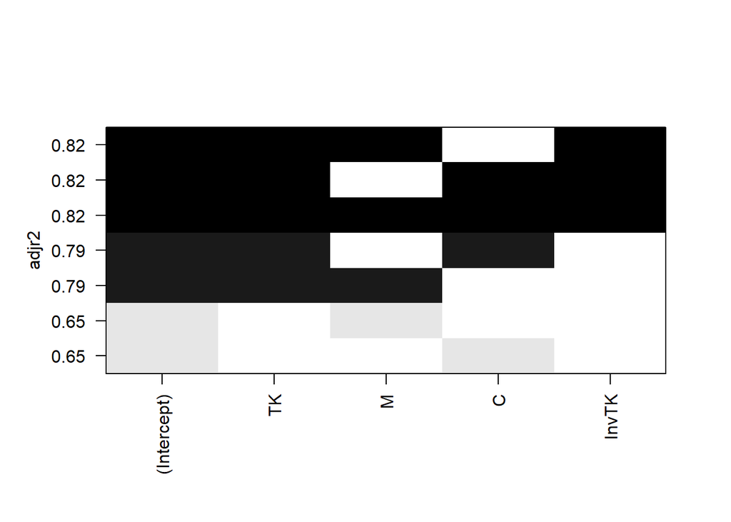

```r
leaps <- regsubsets(TiO2 ~ TK + M + C + InvTK, data = CationFractionsTitanite, nbest = 2)
plot(leaps, scale = "adjr2")
```

- M is in best model fit and C is not, so use M and not C.

### Scatterplot matrices

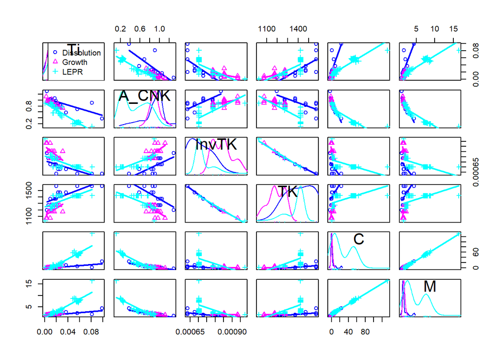

```r
scatterplotMatrix(~ Ti + A_CNK + InvTK + TK + C + M, data = CationFractionsTitanite, groups = CationFractionsTitanite$Source, smooth = FALSE)
```

- LEPR compositions show bimodal distribution for melt composition parameters M and C.

### Preliminary M model fit

```r
RegModel <- CationFractionsTitanite
fit <- lm(TiO2 ~ M + InvTK + TK, data = RegModel)
summary(fit)
```

```
##
## Call:
## lm(formula = TiO2 ~ M + InvTK + TK, data = RegModel)
##
## Residuals:
##     Min      1Q  Median      3Q     Max
## -3.7212 -0.8556 -0.0241  0.7082  5.1012
##
## Coefficients:
##               Estimate Std. Error t value Pr(>|t|)
## (Intercept) -1.027e+02  2.513e+01  -4.086 0.000110 ***
## M            6.798e-01  6.082e-02  11.177  < 2e-16 ***
## InvTK        5.789e+04  1.605e+04   3.606 0.000562 ***
## TK           4.534e-02  9.765e-03   4.643 1.45e-05 ***
## ---
## Signif. codes:  0 '***' 0.001 '**' 0.01 '*' 0.05 '.' 0.1 ' ' 1
##
## Residual standard error: 1.344 on 74 degrees of freedom
## Multiple R-squared:  0.8267, Adjusted R-squared:  0.8196
## F-statistic: 117.6 on 3 and 74 DF,  p-value: < 2.2e-16
```

- TK fits better than InvTK, so drop InvTK

### Refined M model fit

```r
fit <- lm(TiO2 ~ M + TK, data = RegModel)
summary(fit)
```

```
##
## Call:
## lm(formula = TiO2 ~ M + TK, data = RegModel)
##
## Residuals:
##     Min      1Q  Median      3Q     Max
## -2.6132 -0.8784 -0.1874  0.7218  6.4149
##
## Coefficients:
##              Estimate Std. Error t value Pr(>|t|)
## (Intercept) -12.28215    1.81444  -6.769 2.51e-09 ***
## M             0.66831    0.06542  10.216 7.52e-16 ***
## TK            0.01046    0.00143   7.315 2.38e-10 ***
## ---
## Signif. codes:  0 '***' 0.001 '**' 0.01 '*' 0.05 '.' 0.1 ' ' 1
##
## Residual standard error: 1.447 on 75 degrees of freedom
## Multiple R-squared:  0.7962, Adjusted R-squared:  0.7908
## F-statistic: 146.5 on 2 and 75 DF,  p-value: < 2.2e-16
```

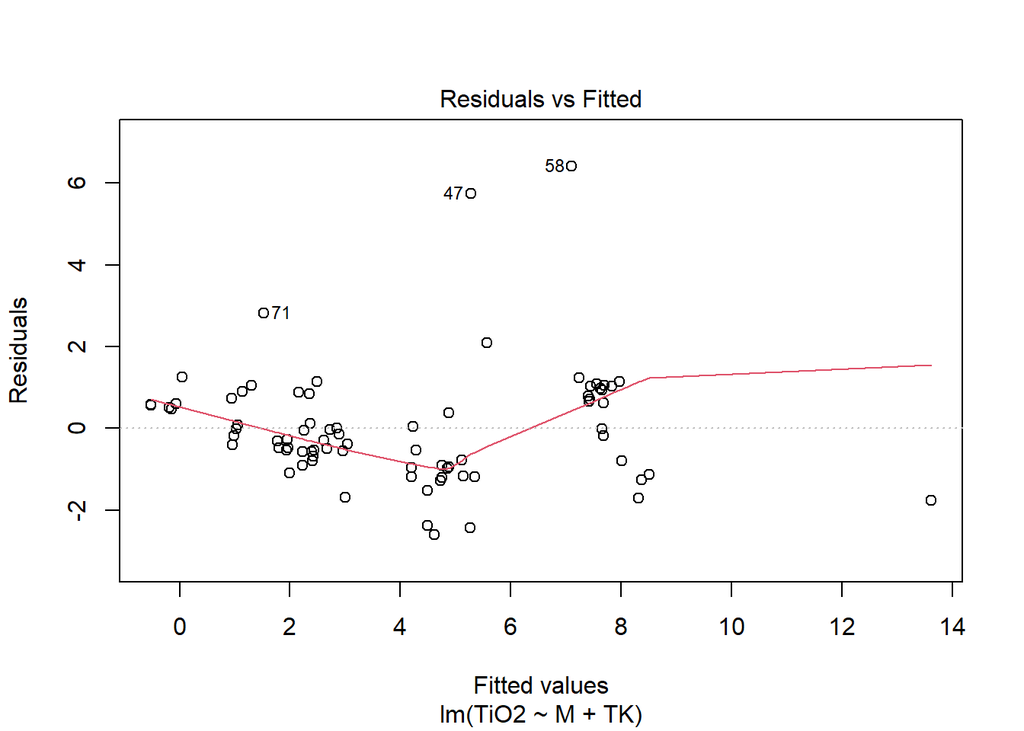

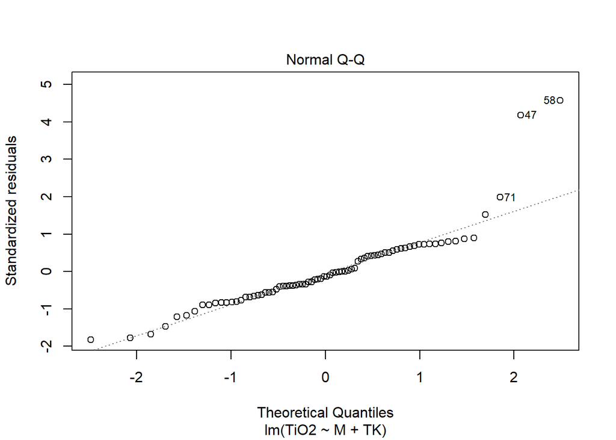

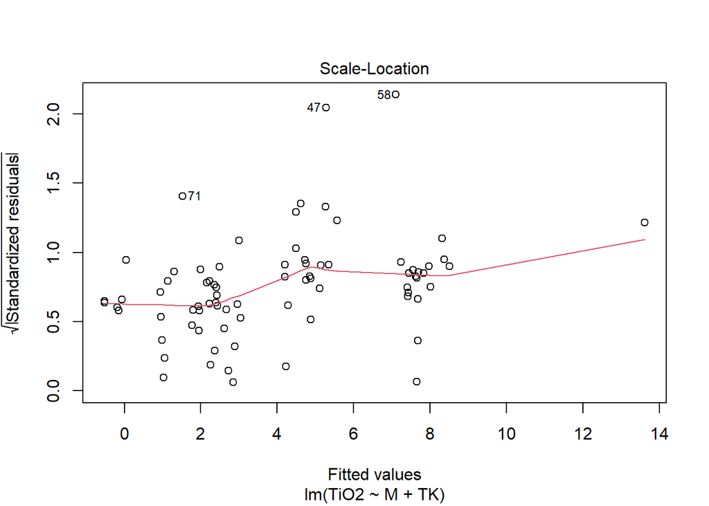

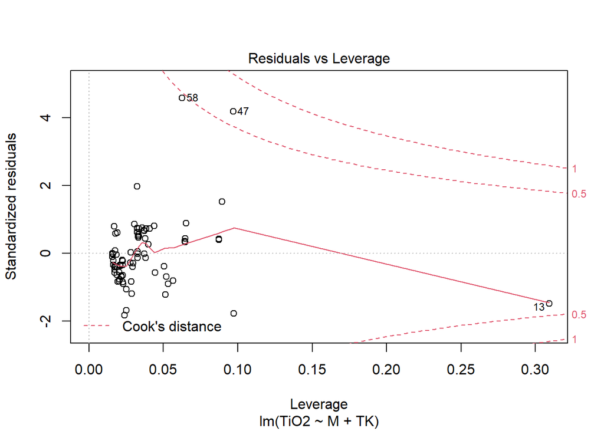

```r
plot(fit)
```

The numbers labeling the outliers correspond to the row numbers of the outlier experiments. At each step I delete all three, refit the model, and then use the plots to identify the next set of three outliers.

```r
DelExpts <- c("SpD_1", "SpD_3", "SpG_28")
RegModel <- filter(RegModel, !(Expt %in%  DelExpts))
fit <- lm(TiO2 ~ M + TK, data = RegModel)
summary(fit)
```

```
##
## Call:
## lm(formula = TiO2 ~ M + TK, data = RegModel)
##
## Residuals:
##     Min      1Q  Median      3Q     Max
## -2.3811 -0.4967 -0.0454  0.7768  3.2060
##
## Coefficients:
##               Estimate Std. Error t value Pr(>|t|)
## (Intercept) -8.5973420  1.2607590  -6.819 2.38e-09 ***
## M            0.7546575  0.0434143  17.383  < 2e-16 ***
## TK           0.0072994  0.0009998   7.301 3.07e-10 ***
## ---
## Signif. codes:  0 '***' 0.001 '**' 0.01 '*' 0.05 '.' 0.1 ' ' 1
##
## Residual standard error: 0.9354 on 72 degrees of freedom
## Multiple R-squared:    0.9,  Adjusted R-squared:  0.8972
## F-statistic: 323.9 on 2 and 72 DF,  p-value: < 2.2e-16
```

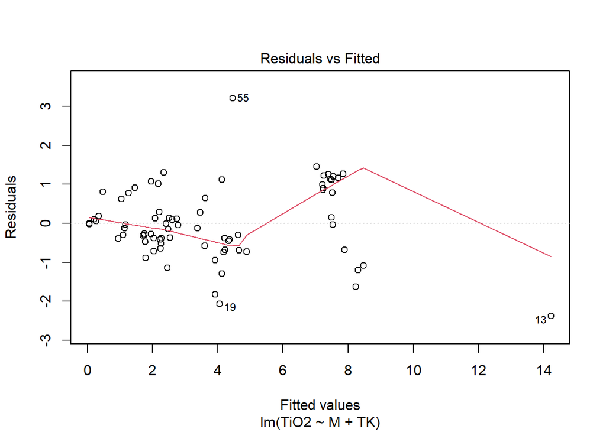

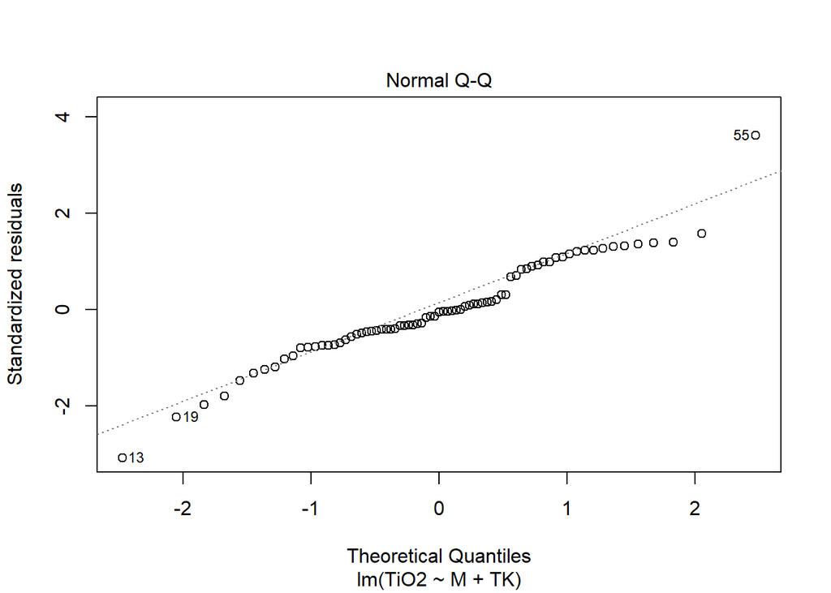

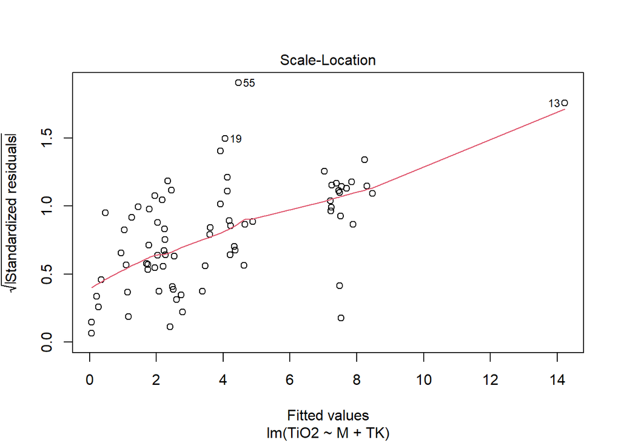

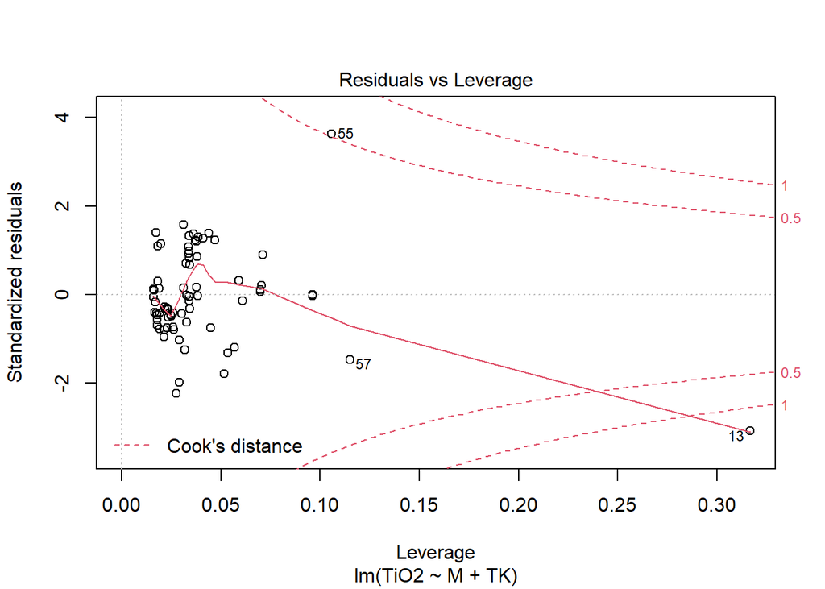

```r
plot(fit)
```

```r
DelExpts <- c("ASI200", "SpD_2", "DAC")
RegModel <- filter(RegModel, !(Expt %in%  DelExpts))
fit <- lm(TiO2 ~ M + TK, data = RegModel)
summary(fit)
```

```
##
## Call:
## lm(formula = TiO2 ~ M + TK, data = RegModel)
##
## Residuals:
##     Min      1Q  Median      3Q     Max
## -2.1030 -0.3499 -0.1394  0.5997  1.4940
##
## Coefficients:
##               Estimate Std. Error t value Pr(>|t|)
## (Intercept) -6.6312897  1.0687198  -6.205 3.55e-08 ***
## M            0.8814308  0.0424409  20.768  < 2e-16 ***
## TK           0.0054896  0.0008646   6.349 1.97e-08 ***
## ---
## Signif. codes:  0 '***' 0.001 '**' 0.01 '*' 0.05 '.' 0.1 ' ' 1
##
## Residual standard error: 0.7401 on 69 degrees of freedom
## Multiple R-squared:  0.9309, Adjusted R-squared:  0.9289
## F-statistic: 464.9 on 2 and 69 DF,  p-value: < 2.2e-16
```

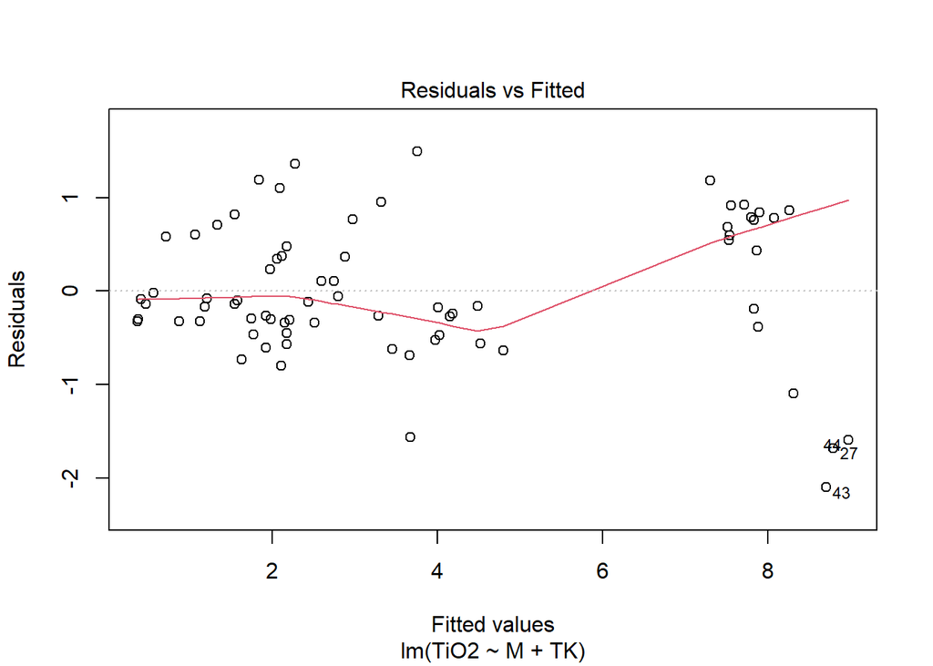

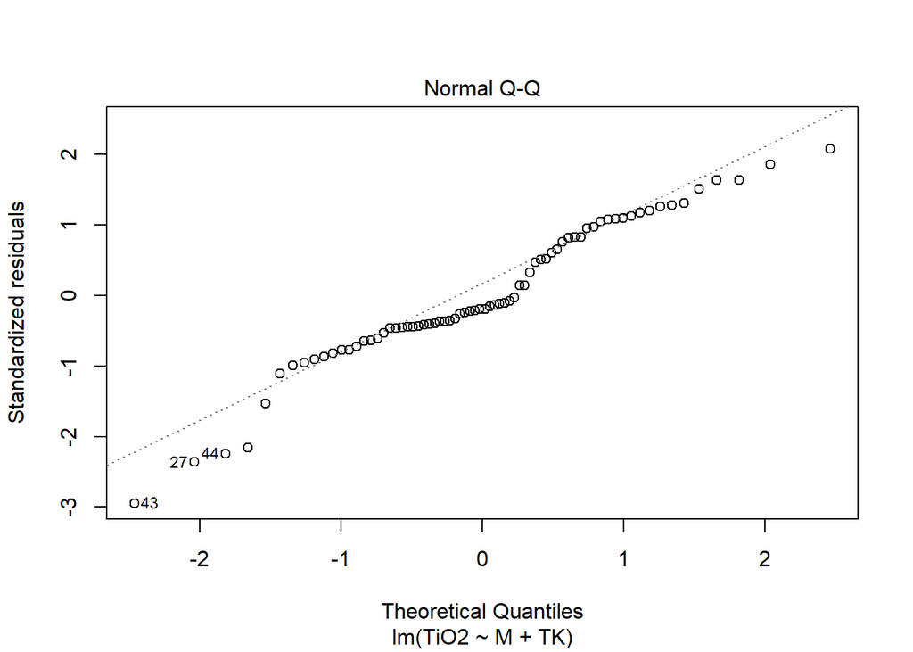

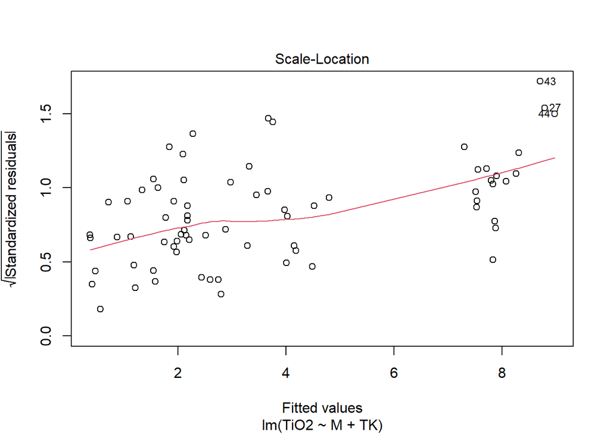

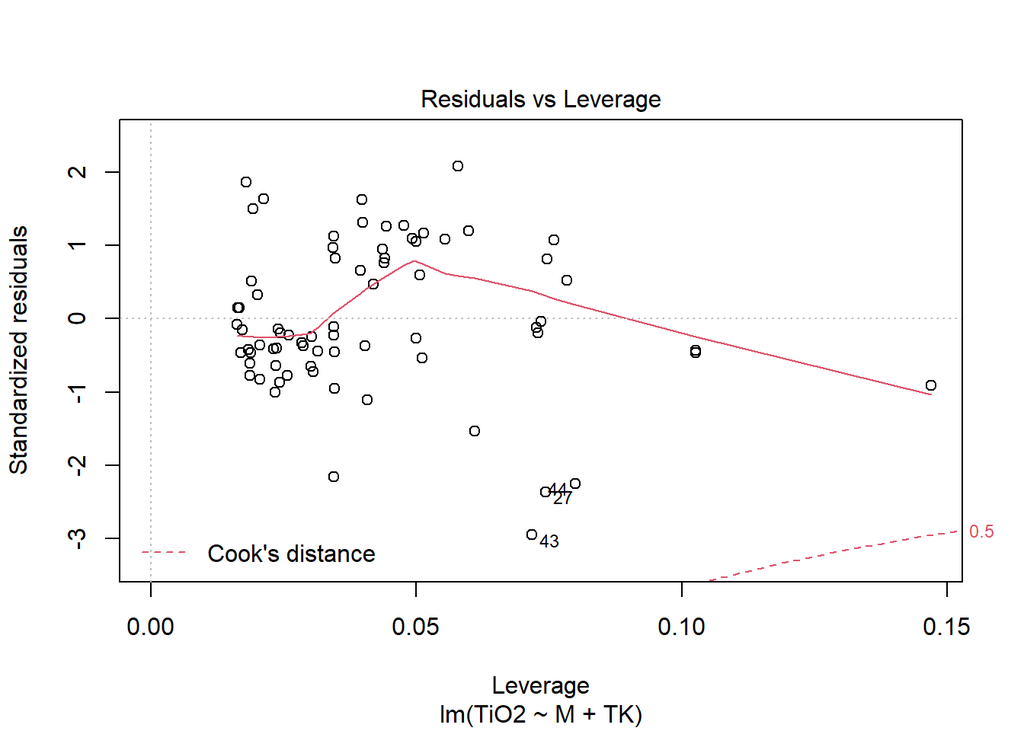

```r
plot(fit)
```

```r
DelExpts <- c("HL220-60000", "SH2Na", "SH2K")
RegModel <- filter(RegModel, !(Expt %in%  DelExpts))
fit <- lm(TiO2 ~ M + TK, data = RegModel)
out <- summary(fit)
out
```

```
##
## Call:
## lm(formula = TiO2 ~ M + TK, data = RegModel)
##
## Residuals:
##     Min      1Q  Median      3Q     Max
## -1.5664 -0.3593 -0.1084  0.3967  1.5434
##
## Coefficients:
##               Estimate Std. Error t value Pr(>|t|)
## (Intercept) -6.2911639  0.8941300  -7.036 1.40e-09 ***
## M            0.9722725  0.0388512  25.026  < 2e-16 ***
## TK           0.0050642  0.0007256   6.979 1.76e-09 ***
## ---
## Signif. codes:  0 '***' 0.001 '**' 0.01 '*' 0.05 '.' 0.1 ' ' 1
##
## Residual standard error: 0.6178 on 66 degrees of freedom
## Multiple R-squared:  0.9509, Adjusted R-squared:  0.9494
## F-statistic: 638.5 on 2 and 66 DF,  p-value: < 2.2e-16
```

```r
Mcoef <- out$coefficients[2,1]
Tcoef <- out$coefficients[3,1]
Int <- out$coefficients[1,1]
RegModel <- RegModel %>%
  mutate(
   TiO2sat = (Mcoef * M + Tcoef * TK + Int)
      )
```

### preliminary M log-log plot

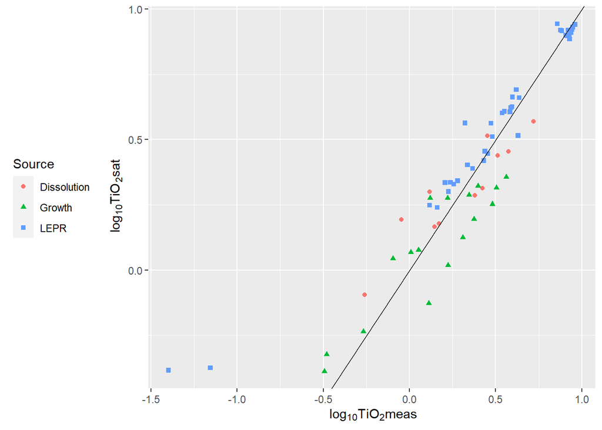

```r
p <- ggplot(RegModel, aes(x = log10(TiO2), y = log10(TiO2sat), shape = Source, color = Source)) +
  geom_point() +
  geom_abline(slope = 1, intercept = 0) +
  theme(legend.position = "left") +
  ylab(~paste("log"[10], "TiO"[2],"sat")) +
  xlab(~paste("log"[10], "TiO"[2],"meas"))
print(p)
```

### Final M model fit

Need to delete the two experiments with the lowest TiO2, since they don’t fall on the trend and are likely below the detection limit

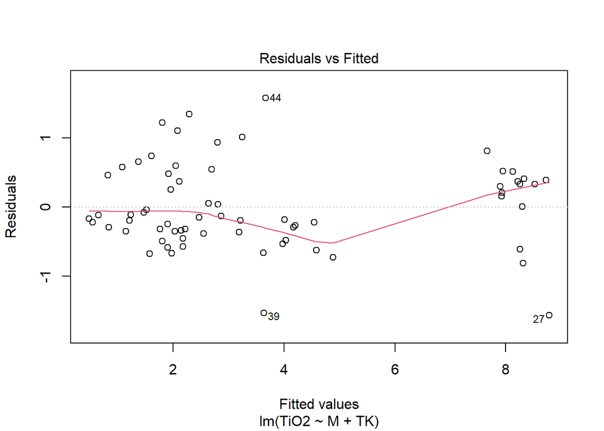

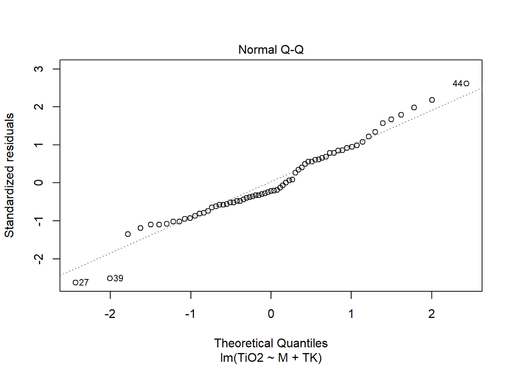

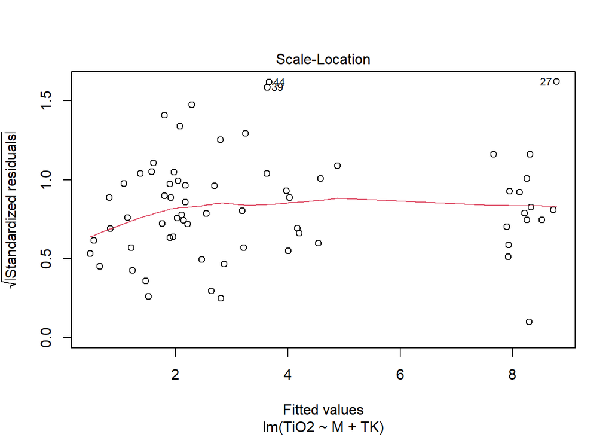

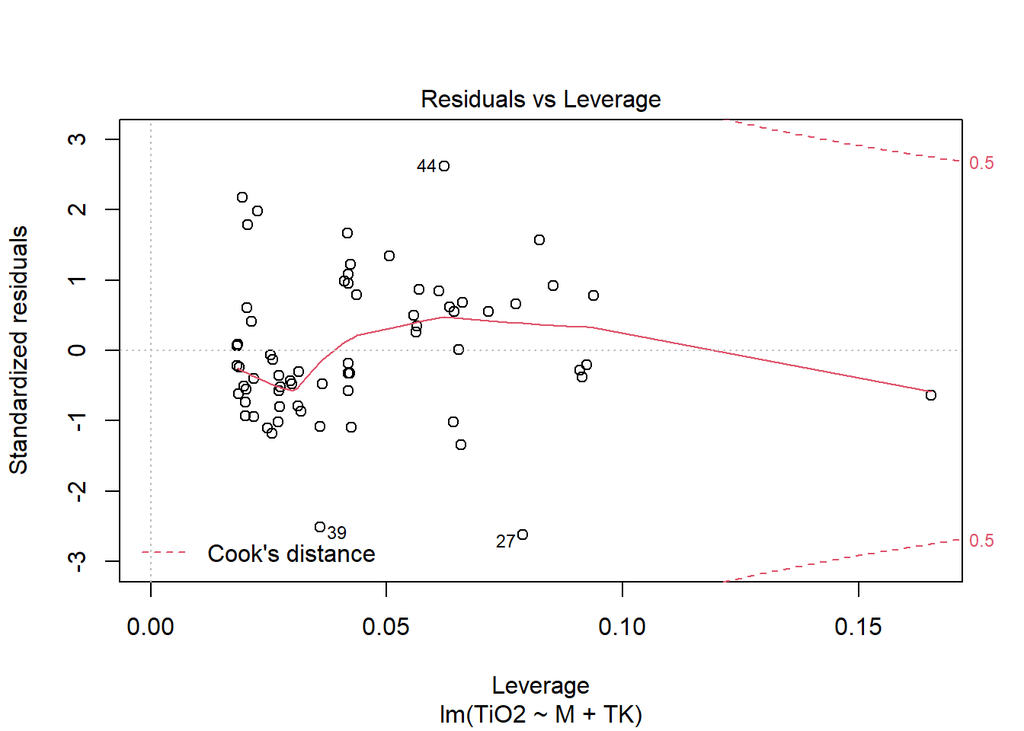

```r
DelExpts <- c("ND-002-18", "ND-002-20")
RegModel <- filter(RegModel, !(Expt %in%  DelExpts))
fit <- lm(TiO2 ~ M + TK, data = RegModel)
out <- summary(fit)
plot(fit)
```

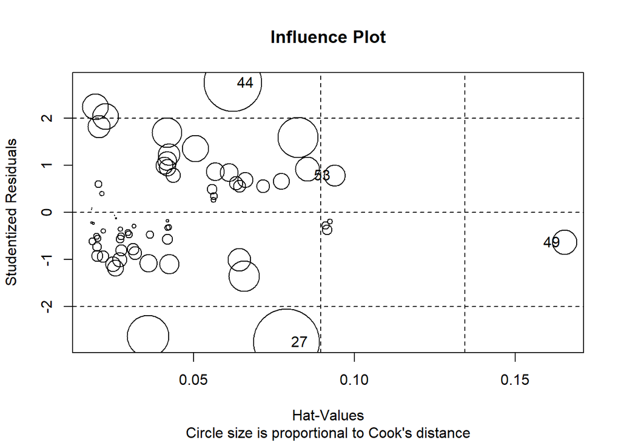

|  | StudRes | Hat | CookD |
| --- | --- | --- | --- |
| 27 | -2.7596396 | 0.07890668 | 0.19709375 |
| 44 | 2.7496026 | 0.06218887 | 0.15157773 |
| 49 | -0.6421435 | 0.16540583 | 0.02749315 |
| 53 | 0.7812960 | 0.09389667 | 0.02121456 |

```r
influencePlot(fit, main="Influence Plot", sub="Circle size is proportional to Cook's distance")
```

### Test of M model regression assumptions

```r
gvmodel <- gvlma(fit)
summary(gvmodel)
```

```
##
## Call:
## lm(formula = TiO2 ~ M + TK, data = RegModel)
##
## Residuals:
##     Min      1Q  Median      3Q     Max
## -1.5714 -0.3601 -0.1328  0.4017  1.5804
##
## Coefficients:
##               Estimate Std. Error t value Pr(>|t|)
## (Intercept) -5.8939753  0.9996174  -5.896 1.52e-07 ***
## M            0.9771707  0.0395525  24.706  < 2e-16 ***
## TK           0.0047608  0.0008026   5.932 1.33e-07 ***
## ---
## Signif. codes:  0 '***' 0.001 '**' 0.01 '*' 0.05 '.' 0.1 ' ' 1
##
## Residual standard error: 0.6232 on 64 degrees of freedom
## Multiple R-squared:  0.9489, Adjusted R-squared:  0.9474
## F-statistic: 594.8 on 2 and 64 DF,  p-value: < 2.2e-16
##
##
## ASSESSMENT OF THE LINEAR MODEL ASSUMPTIONS
## USING THE GLOBAL TEST ON 4 DEGREES-OF-FREEDOM:
## Level of Significance =  0.05
##
## Call:
##  gvlma(x = fit)
##
##                     Value p-value                Decision
## Global Stat        3.8177  0.4312 Assumptions acceptable.
## Skewness           0.4363  0.5089 Assumptions acceptable.
## Kurtosis           0.2881  0.5914 Assumptions acceptable.
## Link Function      1.0153  0.3136 Assumptions acceptable.
## Heteroscedasticity 2.0780  0.1494 Assumptions acceptable.
```

All assumptions satisfied (Peña and Slate 2006)

### Calculate M model TiO2 concentrations and errors

```r
# Model output table provides standard errors; convert to standard deviation by multiplying by sqrt of n = # of samples
n <- nrow(RegModel)
Mcoef <- out$coefficients[2,1]
Mcoefsd <- out$coefficients[2,2]*sqrt(n)
Tcoef <- out$coefficients[3,1]
Tcoefsd <- out$coefficients[3,2]*sqrt(n)
Int <- out$coefficients[1,1]
RegModel <- RegModel %>%
  mutate(
   TiO2sat = (Mcoef * M + Tcoef * TK + Int),
    TiO2satSD = TiO2sat*sqrt(Mcoef^2*Mcoefsd^2 + Tcoef^2*Tcoefsd^2),
   lower = TiO2sat - TiO2satSD,
   upper = TiO2sat + TiO2satSD,
    )
```

### Plot M model TiO2 saturation concentration versus measured TiO2

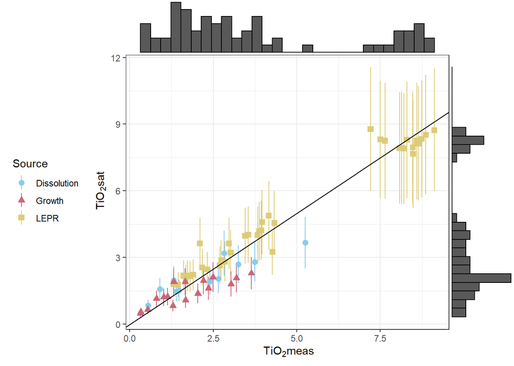

```r
safe_colorblind_palette <- c("#88CCEE", "#CC6677", "#DDCC77", "#117733", "#332288", "#AA4499", "#44AA99", "#999933", "#882255", "#661100", "#6699CC", "#888888", "#0072B2", "#D55E00")
p <- ggplot(data = RegModel, aes(x = TiO2, y = TiO2sat, ymin = lower, ymax = upper, shape = Source, color = Source)) +
  geom_pointrange() +
  scale_color_manual(values=safe_colorblind_palette) +
  theme_bw() +
  geom_abline(slope = 1, intercept = 0) +
  theme(legend.position = "left") +
  ylab(~paste("TiO"[2],"sat")) +
  xlab(~paste("TiO"[2],"meas"))
# add marginal distributions
p1 <- ggMarginal(p, type = "histogram")
print(p1)
```

### final log-log plot of M model fit

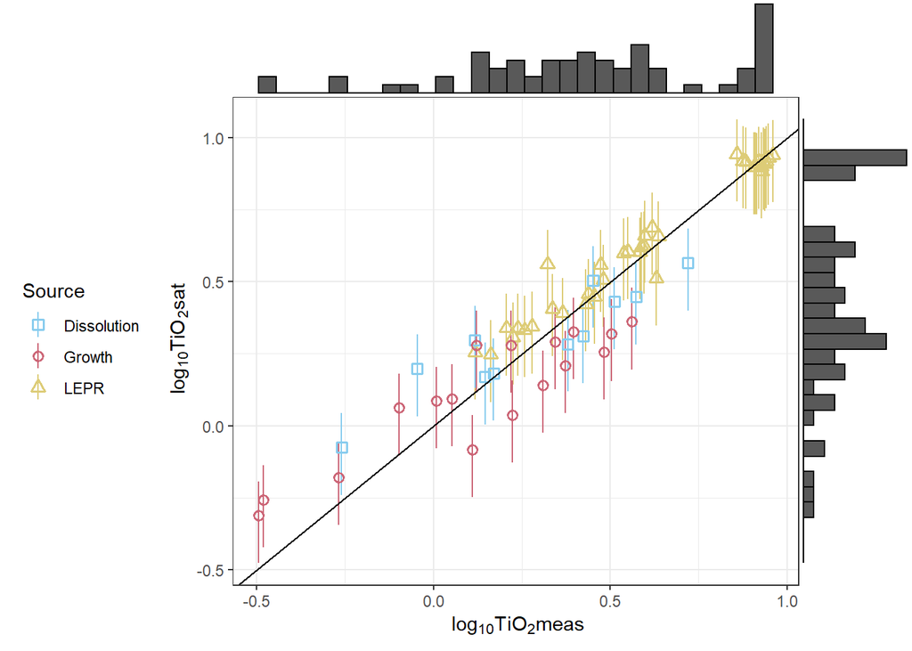

```r
p <- ggplot(RegModel, aes(x = log10(TiO2), y = log10(TiO2sat), ymin = log10(lower), ymax = log10(upper), shape = Source, color = Source)) +
  geom_pointrange() +
   scale_shape_manual(values=c(0, 1, 2)) +
  theme_bw() +
  scale_color_manual(values=safe_colorblind_palette) +
  geom_abline(slope = 1, intercept = 0) +
  theme(legend.position = "left") +
  ylab(~paste("log"[10], "TiO"[2],"sat")) +
  xlab(~paste("log"[10], "TiO"[2],"meas"))
p1 <- ggMarginal(p, type = "histogram")
print(p1)
```

```r
ggsave("Fig5.eps", width = 2000, height = 2*618, units = "px", plot = p1)
```

### TiO2-M-T plot

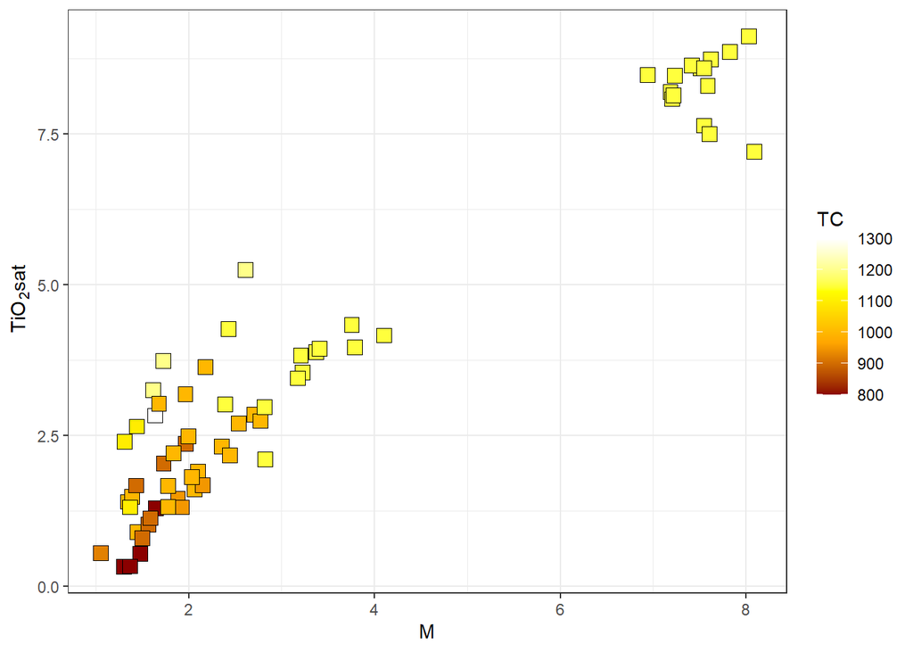

```r
p <- RegModel %>%
ggplot(aes(x=M, y=TiO2, fill = TC)) +
  geom_point(size = 4, shape = 22, color = "black") +
     theme_bw() +
  ylab(~paste("TiO"[2],"sat")) +
 scale_fill_gradientn(colours = c("darkred", "orange", "yellow", "white"))
print(p)
```

```r
ggsave("Fig7.png", width = 2000, height = 2*618, units = "px", plot = p)
```

### TiO2-TK plot

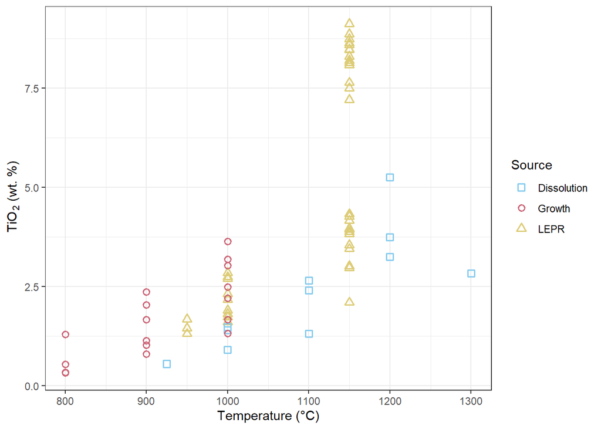

```r
p <- ggplot(RegModel, aes(x=TC, y=TiO2, shape = Source, color = Source)) +
  geom_point(size = 2, stroke = 1) +
  scale_shape_manual(values=c(0, 1, 2)) +
  scale_color_manual(values=safe_colorblind_palette) +
  ylab(~paste("TiO"[2]," (wt. %)")) +
  xlab("Temperature (°C)") +
   theme_bw()
print(p)
```

```r
ggsave("Fig6a.eps", width = 2000, height = 2*618, units = "px", plot = p)
```

### TiO2-M plot

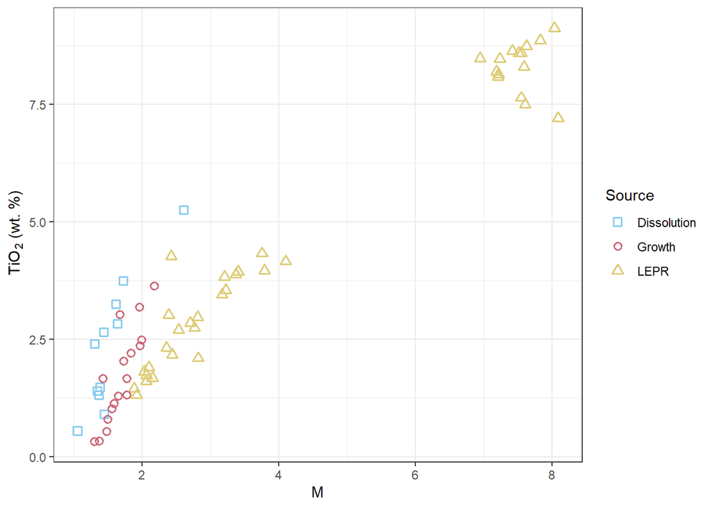

```r
p <- ggplot(RegModel, aes(x=M, y=TiO2, shape = Source, color = Source)) +
  geom_point(size = 2, stroke = 1) +
  scale_shape_manual(values=c(0, 1, 2)) +
  scale_color_manual(values=safe_colorblind_palette) +
  ylab(~paste("TiO"[2]," (wt. %)")) +
  xlab("M") +
   theme_bw()
print(p)
```

```r
ggsave("Fig6b.eps", width = 2000, height = 2*618, units = "px", plot = p)
```

### TiO2 - A/CNK plot

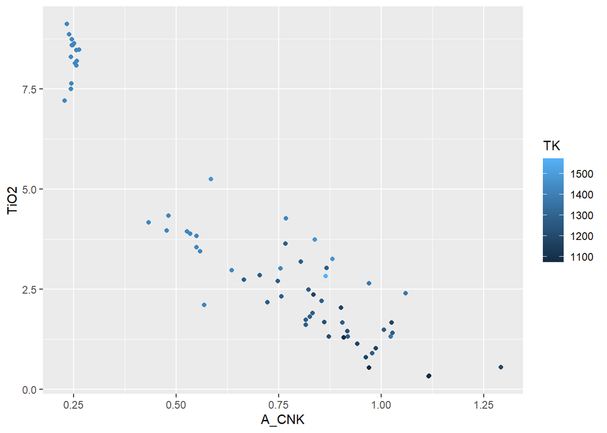

```r
ggplot(RegModel, aes(x=A_CNK, y=TiO2, color=TK)) +
  geom_point()
```

### Model output table

```r
TiO2AllExptsModelTable <- select(RegModel, Source, Expt, TiO2, CaO, M, FM, A_CNK, A_NK, A_C, TK, TiO2sat, TiO2satSD)
write.csv(TiO2AllExptsModelTable, file = "TiO2AllExptsM_ModelTable.csv")
DFGlassComps <- filter(RegModel, Source != "LEPR") %>%
  select(Expt, SiO2:TiO2, M, FM, A_CNK, A_NK, A_C)
write.csv(DFGlassComps, file = "DFGlassCompositions.csv")
```

### M model titanite saturation test

Use M model equation to test whether LEPR expts without titanite or rutile are undersaturated.

```r
LEPR_Expts <- read_csv("LEPR_ExperimentsV2.csv")
LEPRLiqs <- read_csv("LEPR_LiquidAnhyV4.csv")
LEPR <- inner_join(LEPR_Expts, LEPRLiqs, by = "Index")
LEPRnoTitRut <- filter(LEPR, !(grepl("tit|rut", Phases))) %>%
  mutate(
    FeOt = FeO + (2*71.85*Fe2O3)/159.69,
    TK = T_C + 273.15,
    Tot = SiO2 + TiO2 + Al2O3 + FeOt + MgO + CaO + Na2O + K2O) %>%
  filter(Tot > 90)
LEPRnoTitRut <- select(LEPRnoTitRut, Experiment.x, TK, SiO2, TiO2, Al2O3, FeOt, MgO, CaO, Na2O, K2O, Tot)   %>%
  mutate(
    SiO2 = 100*SiO2/Tot,
    TiO2 = 100*TiO2/Tot,
    Al2O3 = 100*Al2O3/Tot,
    FeOt = 100*FeOt/Tot,
    MgO = 100*MgO/Tot,
    CaO = 100*CaO/Tot,
    Na2O = 100*Na2O/Tot,
    K2O = 100*K2O/Tot,
    Tot = SiO2 + TiO2 + Al2O3 + FeOt + MgO + CaO + Na2O + K2O
  )
```

#### Calculate concentrations of cations

```r
LEPRnoTitRutCations <- LEPRnoTitRut %>%
  mutate(
    Si = SiO2/60.0848,
    Al = 2*Al2O3/101.961,
    Na = 2*Na2O/61.979,
    K = 2*K2O/94.194,
    Ca = CaO/56.0794,
    Fe = FeOt/71.8464,
    Mg = MgO/40.3044,
    Ti = TiO2/79.8988,
    eCa = (CaO/56.0794 - Al2O3/101.961 + K2O/94.194 + Na2O/61.979),
    CationSum = (Si + Al + Na + K + Ca + Fe + Mg + Ti)
     )
```

#### Calculate cation fractions

```r
LEPRnoTitRutCationFractions <- LEPRnoTitRutCations
f <- match("Si", names(LEPRnoTitRutCationFractions))
l <- match("Ti", names(LEPRnoTitRutCationFractions))
for (i in f:l) {
  LEPRnoTitRutCationFractions[(i)] = LEPRnoTitRutCationFractions[(i)]/LEPRnoTitRutCationFractions$CationSum
}
```

#### Calculate melt composition parameters

```r
LEPRnoTitRutCationFractions <- LEPRnoTitRutCationFractions %>%
  mutate(
    M = (Na + K + 2*Ca)/(Si*Al),
    C = (10*eCa)/(Si*Al),
    )
```

#### Compare model and observations

```r
NoTitaniteModelM <- select(LEPRnoTitRutCationFractions, Experiment.x, TiO2, TK, M)
NoTitaniteModelM$TiO2sat <- predict(fit, NoTitaniteModelM)
CompareTiO2 <- select(NoTitaniteModelM, Experiment.x,  TiO2, TiO2sat)
CompareTiO2 <- CompareTiO2 %>%
  mutate(
    Model_Correct = if_else(TiO2sat > TiO2, "true", "false")
  )
CompareTiO2
```

| Experiment.x | TiO2 | TiO2sat | Model_Correct |
| --- | --- | --- | --- |
| 11 | 0.166889159 | 0.289371376 | true |
| 12 | 0.199379219 | 0.339845871 | true |
| ND-002-3 | 0.120421475 | 0.661096096 | true |
| ND-002-7 | 0.080345486 | 0.361391286 | true |
| ND-002-10 | 0.130325810 | 0.725235531 | true |
| ND-002-11 | 0.090297991 | 0.602051861 | true |
| ND-002-15 | 0.090288925 | 0.734877054 | true |
| ND-002-16 | 0.110408508 | 0.619976736 | true |
| ND-002-21 | 0.110831233 | 0.429985576 | true |
| ND-002-22 | 0.140618721 | 0.609157993 | true |

[output cut: 2334 more lines]

```r
CompareTiO2 %>%
  count(Model_Correct)
```

| Model_Correct | n |
| --- | --- |
| false | 126 |
| true | 2218 |

- M model correctly predicts undersaturation in 95% of experiments.

```r
save.image("TitaniteAllExptsM.RData")
```

### References

Hirschmann, Marc M, M S Ghiorso, Fred A Davis, S M Gordon, S Mukherjee, T L Grove, M Krawczynski, E Medard, and C B Till. 2008. “Library of Experimental Phase Relations (LEPR): A database and Web portal for experimental magmatic phase equilibria data.” *Geochemistry, Geophysics, Geosystems* 9 (3).

Peña, Edsel A, and Elizabeth H Slate. 2006. “Global Validation of Linear Model Assumptions.” *Journal of the American Statistical Association* 101 (473): 341–54.

Ryerson, F J, and E B Watson. 1987. “Rutile saturation in magmas: implications for Ti-Nb-Ta depletion in island-arc basalts.” *Earth and Planetary Science Letters* 86: 225–39.